# Open-Data Übung: Gemeinden der Schweiz

CAS Datenanalyse, HS 18

Modul grafische Datenexploration und Datenvisualisierung, Dr. Oliver Hümbelin

[figure not shown]

## Einleitung

Ziel dieser Übung ist es, die im Modul „Graphische Datenexploration und Datenvisualisierung“ vermittelten Techniken anzuwenden. Grundlage dafür ist ein Datensatz mit dem regionalen Portrait der Schweizer Gemeinden des Jahres 2014, der über das Open-Data Portal des Bundes frei zugänglich ist (https://opendata.swiss/de/dataset/regionalportrats-2014-kennzahlen-aller-gemeinden/resource/63a4f255-28f3-4568-8e3a-75e3aa466e6b). Der auf Moodle abgelegte Datensatz ist bereits mit einzelnen Merkmalen zur räumlichen Gliederung der Schweiz ergänzt: - Kanton - Grossregionen der Schweiz - Sprachgebiete - Städtische/Ländliche Gebiete

Zusatzerläuterungen zu den Daten finden Sie in den Dokumenten: - be-b-00.04-rgs-15.xls (Raumgliederung Schweiz) - je-d-21.03.01.xls (Kennzahlen Regionalportrait)

Es handelt sich um einen Datensatz, der nicht explizit für Analysezwecke aufbereitet ist, vielmehr ist das Regionalportrait eine Sammlung unterschiedlichster Kennzahlen. Eine erste Übertragung in ein einheitliches Datenformat ist im File gemeindedaten.csv vorgenommen. Ansonsten sind die Daten aber frisch aus dem Netz. Was können wir daraus über die Gemeinden in der Schweiz in Erfahrung bringen?

## Teil 1: Laden des Datensatzes und erste (nicht visuelle) Begutachtung

### 1.Laden Sie den Datensatz gemeindedaten.csv

```r
setwd("~/Desktop/Arbeit/Lehre/CAS DA/Modul Datenvisualisierung/Unterrichtsunterlagen/CAS Datenanalyse HS 18/Ubungsdaten Regionale Porträts der Schweiz/")
gemeindedaten<-read.csv("gemeindedaten.csv",
                          encoding="UTFA-8")
```

### 2. Verschaffen Sie sich einen ersten Überblick zu den Daten.

Hat mit dem Einlesen alles wie erwartet geklappt?  
Sind die Daten so kodiert, wie Sie es erwarten?  
Stimmen die Datenformate der Variablen?  
Gibt es fehlende Werte und wie sind diese kodiert?

```r
str(gemeindedaten)
```

```
#> 'data.frame':    2324 obs. of  51 variables:
#>  $ bfsid           : int  1 2 3 4 5 6 7 8 9 10 ...
#>  $ gmdename        : Factor w/ 2324 levels "Aadorf","Aarau",..: 21 23 247 871 880 1007 1035 1242 1289 1489 ...
#>  $ kantone         : Factor w/ 26 levels "AG","AI","AR",..: 26 26 26 26 26 26 26 26 26 26 ...
#>  $ grossregionen   : Factor w/ 7 levels "Espace Mittelland",..: 7 7 7 7 7 7 7 7 7 7 ...
#>  $ sprachregionen  : Factor w/ 4 levels "deutsch","franzoesisch",..: 1 1 1 1 1 1 1 1 1 1 ...
#>  $ stadt_land      : Factor w/ 4 levels "Agglo","isolierte Stadt",..: 1 1 1 4 1 4 1 4 1 1 ...
#>  $ bev_total       : int  1959 11552 5287 3467 3651 1014 2037 665 4473 4927 ...
#>  $ bev_1014        : num  7.4 4.16 2.48 3.18 7.07 ...
#>  $ bev_dichte      : num  248 1091 712 255 559 ...
#>  $ bev_ausl        : num  13.3 26.7 14.1 13.6 14.8 ...
#>  $ alter_0_19      : num  21.5 20.2 24.5 22.8 22.5 ...
#>  $ alter_20_64     : num  62.6 63 61.4 60.4 63.4 ...
#>  $ alter_65.       : num  15.9 16.9 14.1 16.8 14.1 ...
#>  $ bevbew_heirat   : num  4.58 5.15 5.5 3.19 3.04 ...
```

[output cut: 37 more lines]

```r
# Laden Sie benötigte Packages
library(ggplot2)
library(dplyr)
```

### 3. Falls nötig, definieren Sie im dataframe fehlende Werte so, dass R diese tatsächlich als fehlende Werte auffasst.

```r
# Parteienvariable polit_pda ist komisch
str(gemeindedaten$polit_pda)
```

```
#>  Factor w/ 1011 levels "*","0.005267",..: 268 290 193 296 323 382 7 523 227 153 ...
```

```r
# Histogram plotten ist nicht möglich mit falscher Kodierung
ggplot(gemeindedaten,aes(x=polit_pda))+
  geom_histogram()
```

```
#> Error: StatBin requires a continuous x variable the x variable is discrete. Perhaps you want stat="count"?
```

```r
# Kodierung anpassgen
gemeindedaten$polit_pda[gemeindedaten$polit_pda=="*"]<-NA
gemeindedaten$polit_pda<-as.numeric(as.character(gemeindedaten$polit_pda)) # Format anpassen
```

```
#> Warning: Removed 1311 rows containing non-finite values (stat_bin).
```

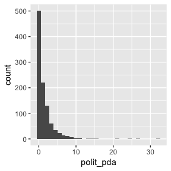

```r
# So geht es. Wir sind startklar
ggplot(gemeindedaten,aes(x=polit_pda))+
  geom_histogram()
```

### 4. Beantworten Sie folgende Fragen:

Wie viele Gemeinden gab es in der Schweiz im Jahr 2014?

```r
nrow(gemeindedaten)
```

```
#> [1] 2324
```

Was ist die mittlere Einwohnerzahl einer Schweizer Gemeinde?  
Wie viele Einwohner leben in der grössten Gemeinde? Wie viele in der kleinsten?

```r
summary(gemeindedaten$bev_total)
```

```
#>    Min. 1st Qu.  Median    Mean 3rd Qu.    Max.
#>      13     615    1396    3545    3397  391359
```

## Teil 2 und 3: Graphische Datenexploration und eine “hübsche” Datenvisualisierung

Ich finde das black-and-white-theme am übersichtlichsten und setze daher dieses theme als Default für die gesamte Session.

```r
theme_set(theme_bw())
```

Jede Grafik wird “aufgehübscht”, d.h. die Grafiken werden möglichst aussagekräftig beschriftet, damit sie selbsterklärend sind. Zude habe ich als Füllfarbe #687d8e verwendet. Ein Dunkelgrau, dass dem CI der BFH entspricht.

### 5. In welchem Kanton gibt es am meisten Gemeinden? In welchem am wenigsten?

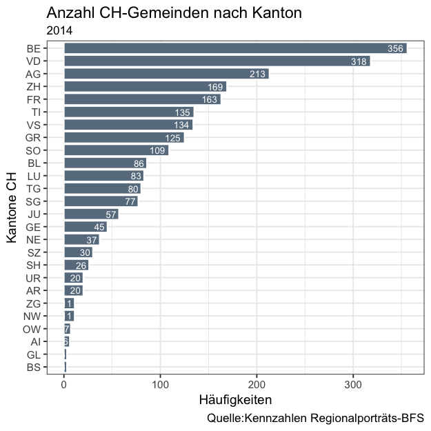

```r
# Anzahl Gemeinden je Kanton als Daten
gemeinden<-
  gemeindedaten %>%
  group_by(kantone)%>%
  summarise(count = n_distinct(bfsid))

ggplot(gemeinden,aes(x=reorder(kantone,count),y=count))+
  geom_bar(stat="identity",color="white",fill="#687d8e",color="grey50")+
  coord_flip()+
  geom_text(aes(label=count),hjust=1.25,colour="white",size=2.75)+
  labs(title="Anzahl CH-Gemeinden nach Kanton",subtitle="2014", y="Häufigkeiten",x="Kantone CH",
       caption="Quelle:Kennzahlen Regionalporträts-BFS")
```

### 6. Betrachten Sie die Einwohnerzahlen der Gemeinden gruppiert nach Sprachregionen. Wie heissen die jeweils grössten Gemeinden?

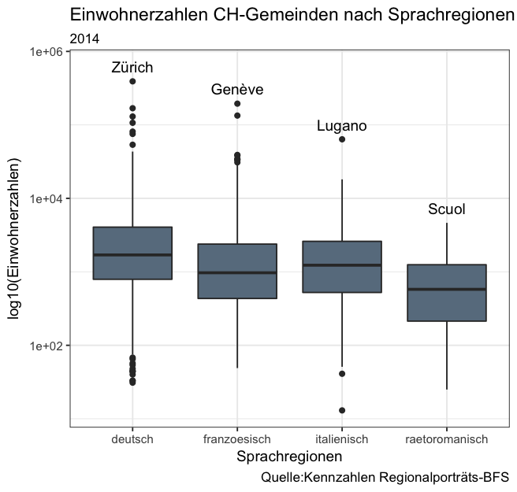

```r
# Datensatz mit jeweils maxmial-Wert je Sprachregion erstellen für Beschriftung erstellen
gd_max <-gemeindedaten %>%
  group_by(sprachregionen) %>%
  filter(bev_total==max(bev_total))

ggplot(gemeindedaten,aes(x=factor(sprachregionen),y=bev_total))+
  geom_boxplot(fill="#687d8e")+
  scale_y_log10()+
  geom_text(data=gd_max,label=gd_max$gmdename,nudge_y=0.2)+
  labs(title="Einwohnerzahlen CH-Gemeinden nach Sprachregionen",subtitle="2014",y="log10(Einwohnerzahlen)",x="Sprachregionen",
       caption="Quelle:Kennzahlen Regionalporträts-BFS")
```

### 7a) Betrachten Sie die Veränderung der Einwohnerzahl von 2010 bis 2014 nach Sprachregionen. In welcher Sprachregionen sind die Gemeinden am stärksten gewachsen? In welcher am wenigsten oder gibt es Sprachregionen, in welcher die Einwohnerentwicklung in der Tendenz sogar eher rückläufig ist?

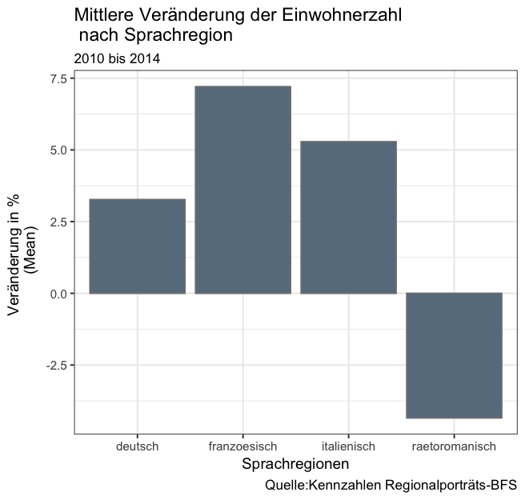

```r
ggplot(gemeindedaten,aes(x=factor(sprachregionen),y=bev_1014))+
  geom_bar(position="identity",stat="summary",fun.y="mean",fill="#687d8e",color="grey50")+
   labs(title="Mittlere Veränderung der Einwohnerzahl \n nach Sprachregion",subtitle="2010 bis 2014",y="Veränderung in % \n (Mean)",x="Sprachregionen",
       caption="Quelle:Kennzahlen Regionalporträts-BFS")
```

### 7b) Analysieren sie zusätzlich graphisch, ob die Unterscheidung von städtischen und ländlichen Gemeinden dabei eine Rolle spielt?

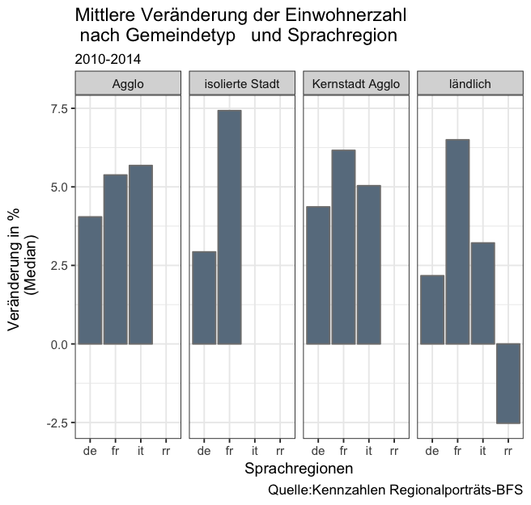

```r
ggplot(gemeindedaten,aes(x=factor(sprachregionen),y=bev_1014))+
  geom_bar(position="identity",stat="summary",fun.y="median",fill="#687d8e",color="grey50")+
  facet_grid(~stadt_land)+
  scale_x_discrete(labels=c("deutsch" = "de", "franzoesisch" = "fr",
                              "italienisch" = "it","raetoromanisch"="rr"))+
  labs(title="Mittlere Veränderung der Einwohnerzahl \n nach Gemeindetyp   und Sprachregion",
       subtitle="2010-2014",y="Veränderung in % \n (Median)",x="Sprachregionen",
       caption="Quelle:Kennzahlen Regionalporträts-BFS")
```

### 8. Untersuchen Sie die Zusammenhangsstruktur folgender Variablen: bev_dichte, bev_ausl, alter_0_19, alter_20_64, alter_65,bevbew_geburt, sozsich_sh, strafen_stgb

Variante 1:

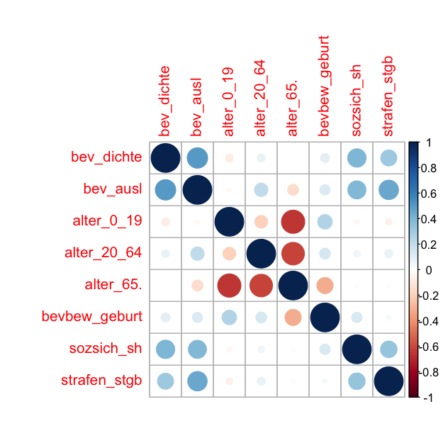

```r
library(corrplot)
corrplot(cor(gemeindedaten[,c(9:13,16,37,49)]))
```

Variante 2:

```r
library(GGally)
```

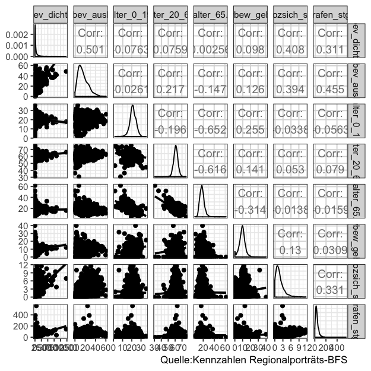

```r
ggpairs(gemeindedaten[,c(9:13,16,37,49)],
        upper = list(continuous="cor"),
        diag = list(continuous="densityDiag"),
        lower = list(continuous="smooth"))+
  labs(caption="Quelle:Kennzahlen Regionalporträts-BFS")
```

### 9. Visualisieren Sie eine Kontingenztabelle mit den Variablen Stadt_Land und Sprachregionen. Welcher Gemeindetyp überwiegt bei deutschsprachigen Gemeinden, welcher bei italienischsprachigen Gemeinden. Gibt es in jeder Sprachregion isolierte Städte?

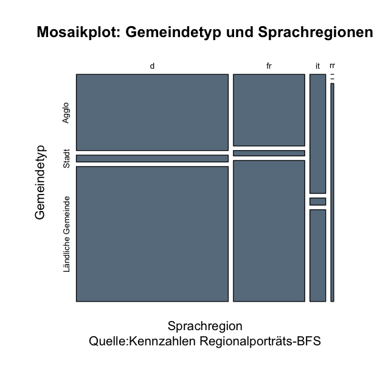

```r
# Neue Variable "gemeindetyp", die Kernstadt Agglo + isolierte Stadt zusammenfasst.
gemeindedaten$gemeindetyp<-gemeindedaten[,"stadt_land"]
levels(gemeindedaten$gemeindetyp)<-c("Agglo","Stadt","Stadt","Ländliche Gemeinde")
table<-table(gemeindedaten$sprachregionen,gemeindedaten$gemeindetyp,dnn=(c("Sprachregion","Gemeindetyp")))
attributes(table)$dimnames$Sprachregion<-c("d","fr","it","rr")

mosaicplot(~Sprachregion + Gemeindetyp,data=table,
           main="Mosaikplot: Gemeindetyp und Sprachregionen",
           sub="Quelle:Kennzahlen Regionalporträts-BFS",
           color="#687d8e")
```

### 10. Erstellen Sie ein politisches Profil nach Sprachregionen mit der Hilfe der Variablen zu den Wähleranteilen.

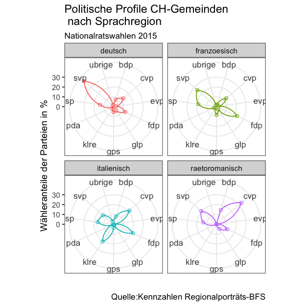

```r
# Daten aufbereiten
# Parteien-Variablen
library(tidyr) # für gather()
profil_sprachregionen <- gemeindedaten %>%
  select(sprachregionen,starts_with("polit")) %>%
  group_by(sprachregionen) %>%
  summarise_all(funs(mean(.,na.rm =TRUE))) %>%
  gather(variable,value,-sprachregionen) %>% # Braucht es hier um das spezifisch benötigte Format zu erhalten
  arrange(variable)

# Data-Polishing
profil_sprachregionen[is.na(profil_sprachregionen)]<-0 # NA führen zu Problem
profil_sprachregionen$variable<-gsub("polit_","",profil_sprachregionen$variable) # Parteien-Variable ohne _polit

# Nun kommen die Radar-Charts
# Mit einem Facet_wrap
ggplot(profil_sprachregionen) +
  aes(x=variable, y=value, group=sprachregionen, color=sprachregionen) +
  geom_polygon(fill=NA) +
  geom_point(shape=21)+
  coord_polar() + facet_wrap(~ sprachregionen) +
  theme(axis.text.x = element_text(size = 10))+
  theme(legend.position = "none")+
  labs(title="Politische Profile CH-Gemeinden \n nach Sprachregion",
       subtitle="Nationalratswahlen 2015",
       y="Wähleranteile der Parteien in %",
       x="",
         caption="Quelle:Kennzahlen Regionalporträts-BFS")
```